# Practical Machine Learning Assignment

Andrew

22/11/2015

# Executive Summary

The goal of your project is to predict the manner in which participants did exercise. The data for this assignment comes from the [Human Activity Recognition](http://groupware.les.inf.puc-rio.br/har) dataset.

# Analysis

First we define helper functions to load additional packages (usePackage) and download/load CSV data (loadCSVData):

```r
rm(list=ls())

usePackage<-function(p){
  # load a package if installed, else load after installation.
  # Args:
  #   p: package name in quotes

  if (!is.element(p, installed.packages()[,1])){
    print(paste('Package:',p,'Not found, Installing Now...'))
    install.packages(p, dep = TRUE)}
  print(paste('Loading Package :',p))
  require(p, character.only = TRUE)
}

loadCSVData<-function(url){
  # saves a data file to a temporary location and loads into memory.
  # dir.create('tmp', showWarnings = FALSE)
  file_name <- basename(url)

  if (file.exists(file_name)) {
   print('Using local file.')
} else {
  print('Downloading file.')
  download.file(url, file_name, method = "curl")
}
  file_data <- read.csv(file_name, na.strings = c("", "NA", "#DIV/0!"))
  return(file_data)
}
```

## Examining Dataset

Using the helper function to download the test and training data from the url’s provided:

```r
train_url <- 'https://d396qusza40orc.cloudfront.net/predmachlearn/pml-training.csv'
test_url <- 'https://d396qusza40orc.cloudfront.net/predmachlearn/pml-testing.csv'

train_data <- loadCSVData(train_url)
```

```
## [1] "Using local file."
```

```r
test_data <- loadCSVData(test_url)
```

```
## [1] "Using local file."
```

and examine the data set (verbose output surpressed) :

We see the class varible in the training data contains 5 categories [A, B, C, D, E]. The objective of this analysis is to classify the test data into one of the five categories. We then clean up the data set, removing the columns that contain mostly N/A’s:

```r
# convert class to factor:
train_data$classe <- as.factor(train_data$classe)
test_data$classe <- NA
levels(test_data$classe) <- levels(train_data$classe)

# removing col with more than 90% N/A's:
na_count_limit <- 0.90

na_per_col <- apply(train_data, 2, function(x) {sum(is.na(x))})
train_data <- train_data[ , which(na_per_col <  nrow(train_data)*na_count_limit)]

keep_col <- names(train_data)
test_data <- test_data[, keep_col]

# removing non relevant columns:
train_data$X <- NULL
train_data$user_name <- NULL
train_data$cvtd_timestamp <- NULL
train_data$new_window <- NULL
train_data$num_window <- NULL
train_data$raw_timestamp_part_1 <- NULL
train_data$raw_timestamp_part_2 <- NULL

test_data$X <- NULL
test_data$new_window <- NULL
test_data$num_window <- NULL
test_data$raw_timestamp_part_1 <- NULL
test_data$raw_timestamp_part_2 <- NULL
```

## Fitting Model

We divide the training data into two sets (training and validation).

```r
usePackage('caret')
```

```
## [1] "Loading Package : caret"
```

```r
set.seed(1)
train_toggle <- createDataPartition(train_data$classe, p = 0.8, list = FALSE)
training_set <- train_data[train_toggle, ]
validation_set <- train_data[-train_toggle, ]
```

And fit a random forrest model:

```r
usePackage('randomForest')
```

```
## [1] "Loading Package : randomForest"
```

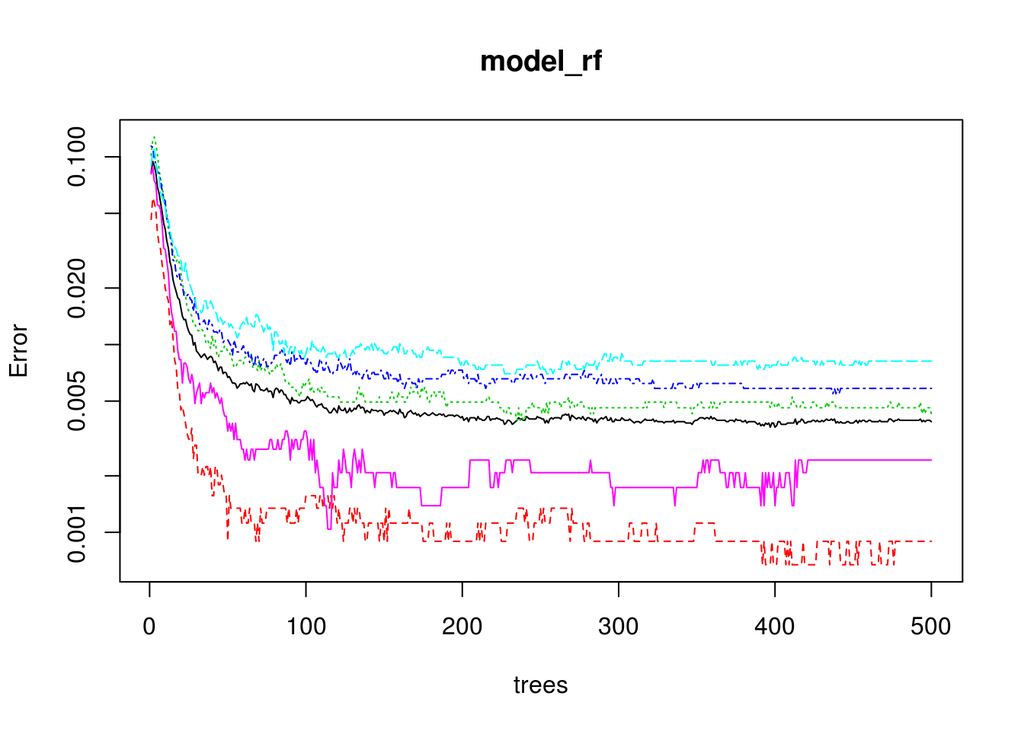

```r
set.seed(1)
model_rf <- randomForest(classe ~ .,  data=training_set, ntrees = 100, na.action = na.omit)
plot(model_rf, log="y")
```

## Examining Model Fit

Examining the model fit to the training data (by fitting the training data):

```r
predict_train <- predict(model_rf, training_set, type = "class")
confusionMatrix(predict_train, training_set$classe)
```

```
## Confusion Matrix and Statistics
##
##           Reference
## Prediction    A    B    C    D    E
##          A 4464    0    0    0    0
##          B    0 3038    0    0    0
##          C    0    0 2738    0    0
##          D    0    0    0 2573    0
##          E    0    0    0    0 2886
##
## Overall Statistics
##
##                Accuracy : 1
##                  95% CI : (0.9998, 1)
##     No Information Rate : 0.2843
##     P-Value [Acc > NIR] : < 2.2e-16
##
##                   Kappa : 1
##  Mcnemar's Test P-Value : NA
##
## Statistics by Class:
##
##                      Class: A Class: B Class: C Class: D Class: E
## Sensitivity            1.0000   1.0000   1.0000   1.0000   1.0000
## Specificity            1.0000   1.0000   1.0000   1.0000   1.0000
## Pos Pred Value         1.0000   1.0000   1.0000   1.0000   1.0000
## Neg Pred Value         1.0000   1.0000   1.0000   1.0000   1.0000
## Prevalence             0.2843   0.1935   0.1744   0.1639   0.1838
## Detection Rate         0.2843   0.1935   0.1744   0.1639   0.1838
## Detection Prevalence   0.2843   0.1935   0.1744   0.1639   0.1838
## Balanced Accuracy      1.0000   1.0000   1.0000   1.0000   1.0000
```

And examining the model fit using the validation data:

```r
predict_validation <- predict(model_rf, validation_set, type = "class")
confusionMatrix(predict_validation, validation_set$classe)
```

```
## Confusion Matrix and Statistics
##
##           Reference
## Prediction    A    B    C    D    E
##          A 1114    2    0    0    0
##          B    2  756    6    0    0
##          C    0    1  675    6    0
##          D    0    0    3  636    1
##          E    0    0    0    1  720
##
## Overall Statistics
##
##                Accuracy : 0.9944
##                  95% CI : (0.9915, 0.9965)
##     No Information Rate : 0.2845
##     P-Value [Acc > NIR] : < 2.2e-16
##
##                   Kappa : 0.9929
##  Mcnemar's Test P-Value : NA
##
## Statistics by Class:
##
##                      Class: A Class: B Class: C Class: D Class: E
## Sensitivity            0.9982   0.9960   0.9868   0.9891   0.9986
## Specificity            0.9993   0.9975   0.9978   0.9988   0.9997
## Pos Pred Value         0.9982   0.9895   0.9897   0.9938   0.9986
## Neg Pred Value         0.9993   0.9991   0.9972   0.9979   0.9997
## Prevalence             0.2845   0.1935   0.1744   0.1639   0.1838
## Detection Rate         0.2840   0.1927   0.1721   0.1621   0.1835
## Detection Prevalence   0.2845   0.1947   0.1738   0.1631   0.1838
## Balanced Accuracy      0.9987   0.9968   0.9923   0.9939   0.9992
```

## Fitting Test Set

Using the random forest model to classify the test data set:

```r
test_class <- predict(model_rf, test_data)
test_class
```

```
##  1  2  3  4  5  6  7  8  9 10 11 12 13 14 15 16 17 18 19 20
##  B  A  B  A  A  E  D  B  A  A  B  C  B  A  E  E  A  B  B  B
## Levels: A B C D E
```

# Conclusions

1, 2, 3, 4, 5, 6, 7, 8, 9, 10, 11, 12, 13, 14, 15, 16, 17, 18, 19, 20,

B, A, B, A, A, E, D, B, A, A, B, C, B, A, E, E, A, B, B, B,

# Submission

Preparing files for submission:

```r
answers <- as.vector(test_class)
pml_write_files = function(x){
  n = length(x)
  for(i in 1:n){
    filename = paste0("problem_id_",i,".txt")
    write.table(x[i],file=filename,quote=FALSE,row.names=FALSE,col.names=FALSE)
  }
}

pml_write_files(answers)
```